# Annual variations of weather variables in the Sartenejas Valley

Rizcalla Antonio Akel Cordovez

2020-07-15

## Description of the Data

The Remote Sensors Laboratory (LSR) of the Simón Bolívar University, attached to the Department of Environmental Studies, maintains a constant record of the values of various environmental variables on the university campus within the Sartenejas Valley, Baruta Municipality, Miranda, with a Vantage Pro2 Plus kit (Davis Instruments). These variables are:

- Atmospheric pressure (inHg)
- Outside temperature (° F)
- RH (%)
- Wind speed (M / h)
- Wind direction (0-360 ° N)
- Burst speed (M / h)
- Burst direction (0-360 ° N)
- Average Rain (in / h)
- Precipitation (in)
- Radiation (W / m2)
1. A manual and visual exploration of the data recorded by the sensors of the LSR of the Simón Bolívar University was carried out. Said records correspond to the time range * 2015-08-02 18:50:00 - 2018-02-01 00:10:00 “America / Caracas” *.
2. The totality of missing or possibly badly recorded data was determined for each variable.
   - Those variables that were considered adequate for this study were selected due to their integrity.
3. For the analysis carried out, a temporal subset of the database was generated with the variables ** dateTime, outTemp, radiation **, from which the following variables were derived:
   - y: Year in which the observation was made.
   - day: Day of the month in which the observation was made.
   - month: Month of the year in which the observation was made.
   - yday: Day of the year in which the observation was made.
   - maxradiation: Maximum radiation recorded on the day and year of the observation (W / m2).
   - maxoutTemp: Maximum temperature recorded on the day and year of the observation (° C).
   - minoutTemp: Minimum temperature recorded on the day and year of the observation (° C).
   - meanoutTemp: Average temperature recorded on the day and year of the observation (° C).

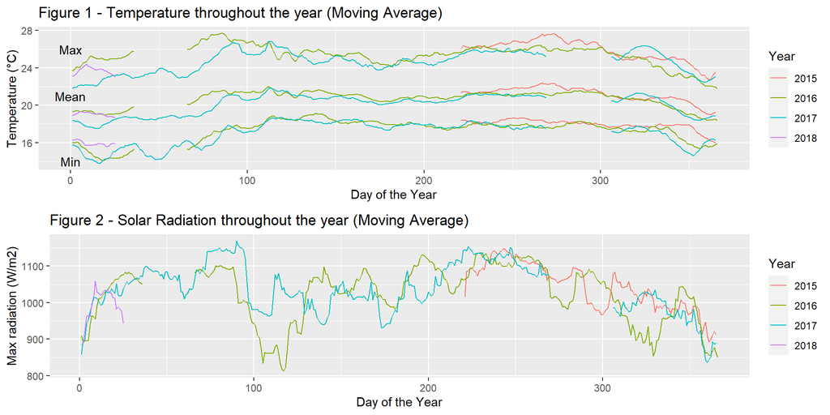

Figure 1 shows how **temperatures** throughout each year seem to behave in a similar way in the same time ranges or seasons. However, for each month there seem to be differences between the maximum, average and minimum values recorded, between 2016 and 2017, with the latter apparently below the previous one in several cases. In the same way, we can observe in Figure 2 that the levels of **maximum registered radiation** seem to have a regular behavior depending on the different seasons or periods of the year. When comparing each year, some differences are observed in the levels of maximum radiation recorded at different points of the year. A difference is especially observed for the end and the beginning of Q1 and Q2, respectively, between the years 2016 and 2017.

### Monthly temperatures

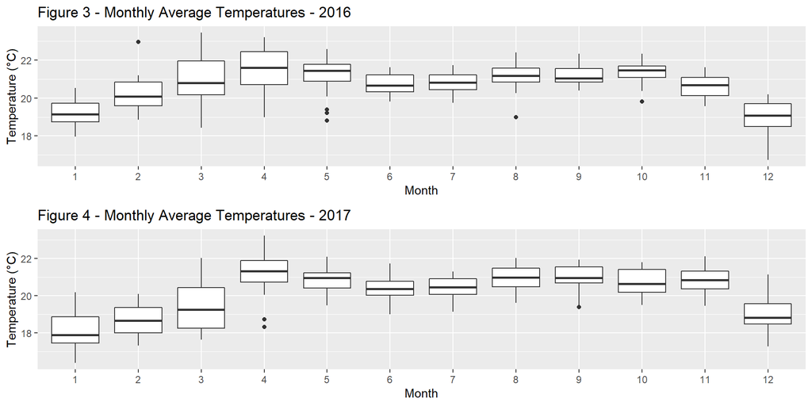

In Figures 3 and 4 it can be seen that the distribution followed by the means seems to be associated with specific seasons and months of the year.

### Monthly radiation

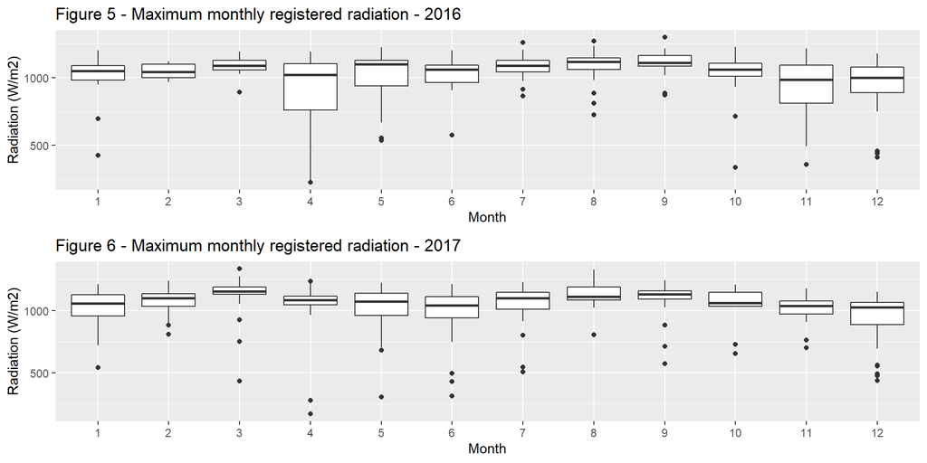

In Figures 5 and 6 we can see that the distribution that the maximum radiation records follow in each month seems to be distributed more or less regularly throughout the year, although it is still possible to see annual maximums and minimums.

## Heatmap example

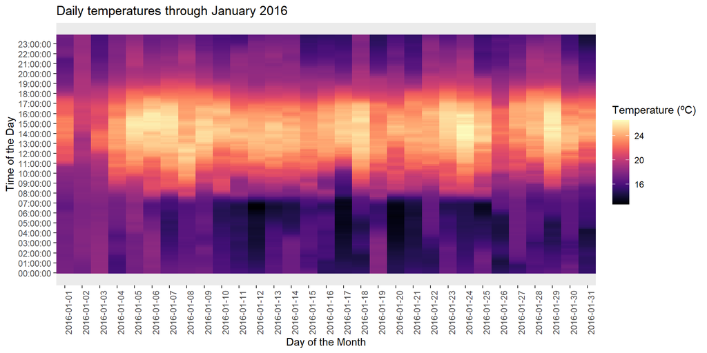

## Animated examples

[figure not shown]

[figure not shown]

___

Code can be consulted in: https://gitlab.com/Rizcalla/Data-Visualization---Example-1.git